# molecool_Module9

molecool

12/10/2021

## Introduction

Who has never wondered where birds went once the weather became really cold while growing up? After all, human beings can easily treat themselves to a warm cup of soup in their heated- houses, and not really worry about groceries as there is a supermarket nearly everywhere nowadays. Birds, on the contrary, and particularly neotropical ones, such as the so-called trans-Gulf migrants (TGMs), usually fly over the Gulf of Mexico on a non-stop route, venturing out every Spring season, and travelling long-distances from Central and South America to higher latitudes for food and breeding opportunities (Newton (2011)). The arrival date for these birds is not a random effect though, for it has direct implications on fitness. In order words, arriving too early can increase and individual’s chances of finding a good mate and procreating, whereas arriving too late can perhaps allow an individual to find more food sources available (Smith and Moore (2005)). Considering the importance of arrival time in the context of a changing climate, studies in the late 90s have shown variation in the arrival time of certain species, such as warblers, on a year to year basis, which was found to be linked to different environmental conditions (Smith and Moore (2005)). However, in what specific ways these birds manage to shift their arrival and whether they actually do so remain up for a debate.

In this project, we will explore available resources like eBird and NOAA’s National Climatic Data Center’s API in order to observe and study the effects of changes in local weather and environmental aspects linked to climate change and how these affect the migration of 10 species of TGMs.

In undertaking these analyses, we focused on a few key questions:

• Is there an actual variation between arrival time and wind variables along migration route for TGMs migrating to MA?

• If so, what role can climate change potentially play in the population status of TGMs arriving in MA during the spring?

• Is there a variation among different species? In other words, does weight affect this variation at all?

• How does this project contribute to, challenge, or refine previous hypothesis concerning the role that climatic variables play in long-distance migration in passerine birds?

Overall, answering these questions will not only provide a better understanding of how and if individual TGMs species are able to adjust their arrival time based on a changing climate and still successfully find suitable mates and food sources, but also show evidence that climate change is an ongoing phenomenon.

## Methods

We decided to study 10 species of birds with varied in size and mass; "Archilochus colubris, Buteo platyperus, catharus ustulatus, Coccyzus erythrophtalmus, Contopus virens, Myiarchus crinitus, Parkesia noveboracensis, Piranga olivacea, Sphyrapicus varius, and Vermivora cyanoptera*. The occurrence data was constrained by species, occurrence within year, our chosen year and month range, occurrence in the U.S and Massachusetts, and so that we only had human observations.We used TGM’s to look at weather along the migration route, and used locations that represented logical sampling locations for the weather data, In Mobile, AL, Boston, MA, and Charlotte, NC. For the data analysis, we computed arrival time for each species by finding the day that corresponded to when 25% of the individuals arrived in a given year. We mutated the weather data to be according to Julian day, and scaled the wind direction to 200 degrees and multiplied by velocity in order to standardize the optimal wind direction. We also multiplied the vector by -1 so that the vector, if negative represents head wind, and if positive represents tailwind. We then joined the bird and weather data with the maximum average masses of the species for data analysis. We used data analysis to answer the question “Does mass of the bird predict arrival time (depending on weather along the migration route)?” Since we had parameters that we saw as important or explanatory, that could contribute to a slope and intercept of the model, we utilized linear mixed effect modeling, where location was specified as a random effect and the fixed effects were wind and mass. We used the dredge function to decompose the models to all the combinations of the terms, including interactions, and to report model fit values (AICc,Δ AIC, and AICw).

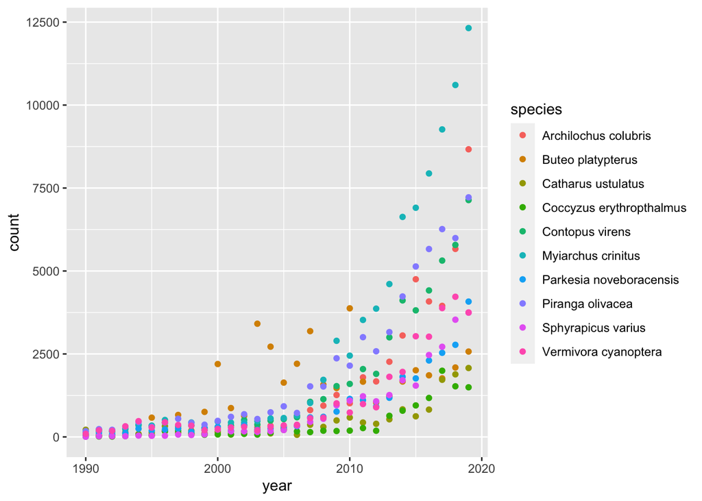

Recorded observations of each species

Fit values for nested models of the lme model

|  | (Intercept) | mass | wk.wvec | mass:wk.wvec | df | logLik | AICc | delta | weight |
| --- | --- | --- | --- | --- | --- | --- | --- | --- | --- |
| 1 | 127.3141 | NA | NA | NA | 3 | -1093.792 | 2193.637 | 0.000000 | 0.987837580 |
| 3 | 127.2997 | NA | 0.0010622 | NA | 4 | -1097.294 | 2202.674 | 9.037639 | 0.010769294 |
| 2 | 127.3987 | -0.0008587 | NA | NA | 4 | -1099.339 | 2206.764 | 13.127936 | 0.001393126 |

## Author Contributions

In an effort to contribute to each other’s learning as a whole, Molecool team members worked together to tackle the code, downloading and normalizing data, culminating in an organized final .Rmd document. Team member Stephanie contributed by helping crack the code, and qualitatively assessing the effects of wind and bird mass and their respective results; team member Jessica contributed to the project by doing research to put together a comprehensive introduction, the bib file, citations, and coding; team member Greg contributed to the project by halping with the code, writing the discussion, and the Rmd file; team member Julia contributed to the project by doing creating a csv file containing bird mass according to species, writing up the methods, and heling crack the code as well.

## References

Alerstam, Thomas. 2011. “Optimal Bird Migration Revised.” *Journal of Ornithology* 152 (September): 5–23. https://doi.org/10.1007/s10336-011-0694-1.

Horton, Kyle G., Benjamin M. Van Doren, Frank A. La Sorte, Emily B. Cohen, Hannah L. Clipp, Jeffrey J. Buler, Daniel Fink, Jeffrey F. Kelly, and Andrew Farnsworth. 2019. “Holding Steady: Little Change in Intensity or Timing of Bird Migration over the Gulf of Mexico.” *Global Change Biology* 25 (3): 1106–18. https://doi.org/https://doi.org/10.1111/gcb.14540.

Newton, I. 2011. “The Ecology of Bird Migration Patterns.” *BOU Proceedings of The Ecology and Conservation of Migratory Birds*.

Smith, Robert J, and Frank R Moore. 2005. “Arrival Timing and Seasonal Reproductive Performance in a Long-Distance Migratory Landbird.” *Behavioral Ecology and Sociobiology* 57 (3): 231–39.